# 07_Exploritory

The first thing we should do with the datasets is to load them into r using the following code.

```r
#Read in the 4 csv files
athletes <- read.csv('./data/athlete_events_data_dictionary.csv',
                     header = TRUE)
events <- read.csv('./data/athlete_events.csv',
                   header = TRUE)
countryDefdd<- read.csv('./data/country_definitions_data_dictionary.csv',
                        header = TRUE)
countryDef <- read.csv('./data/country_definitions.csv',
                       header = TRUE)

#Get a summary view of the data
summary(athletes)
summary(events)
```

[output not shown]

The athletes table is the meta data for the events table. There is a lot of missing data in the events table for height and weight of the athletes. NOC, sex, and year are categorical variables and have been coded as characters or numerical. These will need to be re coded into factors.

```r
summary(countryDefdd)
```

```
##     Field           Description
##  Length:3           Length:3
##  Class :character   Class :character
##  Mode  :character   Mode  :character
```

```r
summary(countryDef)
```

```
##      NOC               region             notes
##  Length:230         Length:230         Length:230
##  Class :character   Class :character   Class :character
##  Mode  :character   Mode  :character   Mode  :character
```

CountryDefdd is the meta data for the countryDef file. These columns are NOC, the region that can be used for geospatial maps and the actual country name if the geospace location is unavailable. The countryDef is the data to represent this information.

Before I try to perform some explorations on the data it is imperative that we clean the data up a bit. Factoring the above variables will help with speed to process the data.

```r
events$Sex <- factor(events$Sex,
                     levels = c("M","F"),
                     labels = c("M","F"))

#years <- distinct(events, Year)
#events$Year <- factor(events$Year,
  #                    levels = years,
  #                    labels = years)
#class(events$Year)
```

From here we can get a breakdown of the number of athletes that compete in each sport since the 2000 Summer games as shown below.

```r
Summer <- events %>% filter (Season == "Summer") %>% filter (Year > 2000)
```

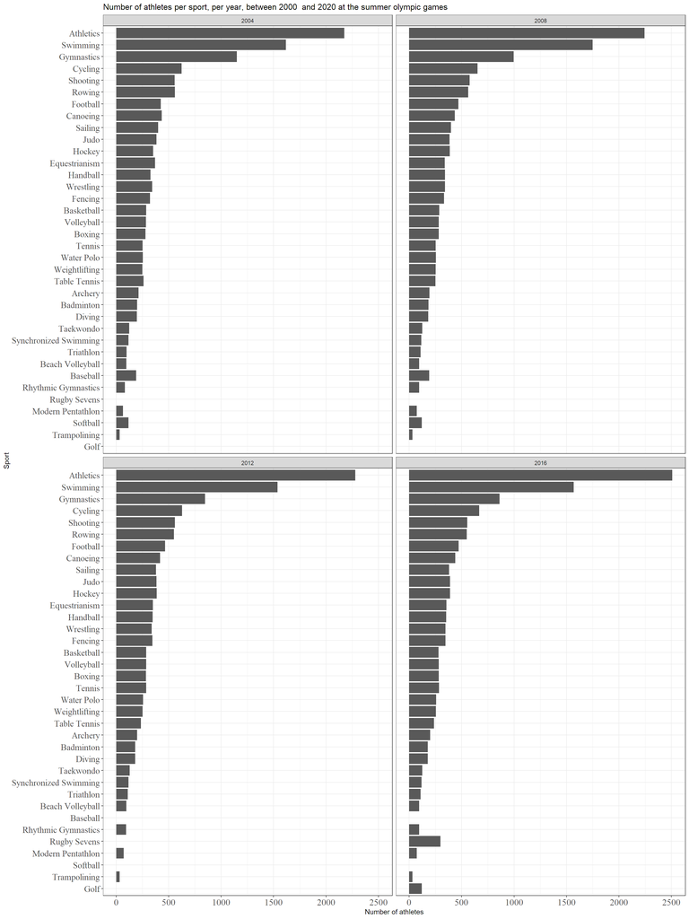

```r
txtTitle <- paste('Number of athletes per sport, per year, between 2000 ',
        'and 2020 at the summer olympic games')
Summer %>%
  ggplot() +
  geom_bar(aes(y = fct_rev(fct_infreq(Sport))), stat="count") +
  labs(title = txtTitle,
       x = "Number of athletes", y = "Sport") +
  theme_bw() +
  theme(axis.text = element_text(family="serif", size = 14)) +
  facet_wrap(vars(Summer$Year))
```

Similarly we can get a break down of the number of competing athletes at the Winter olympic games since 2000

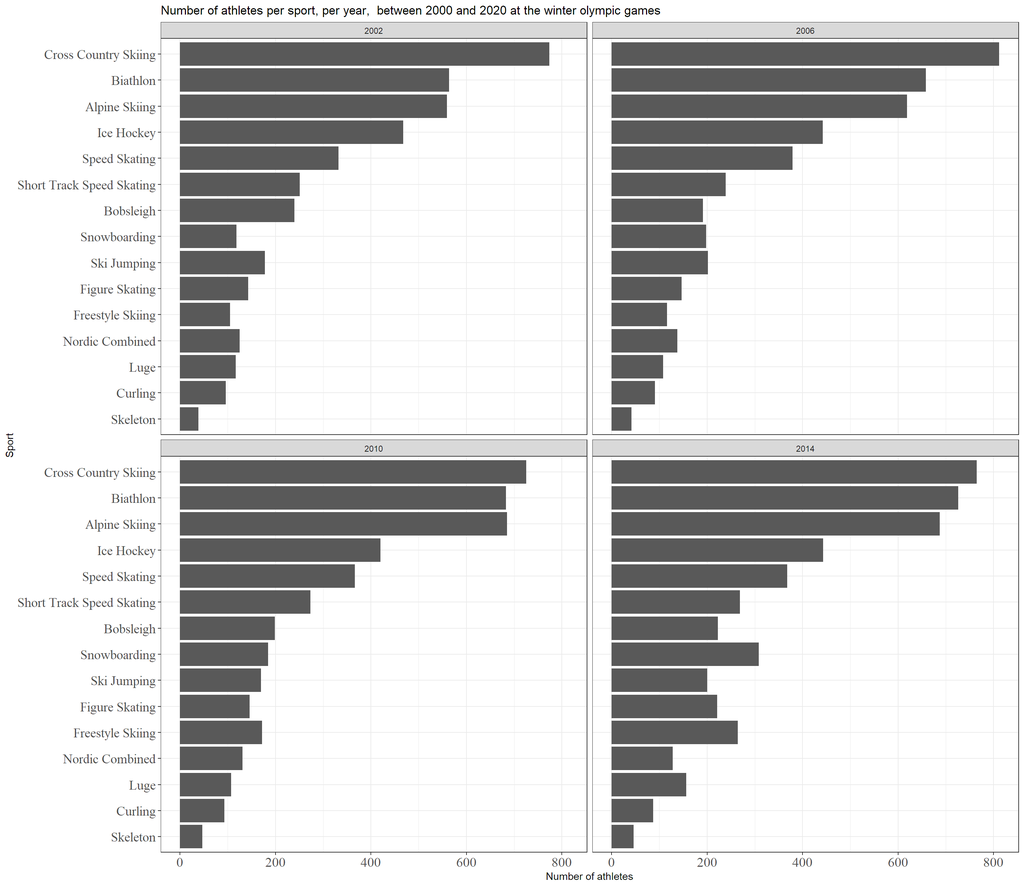

```r
txtTitle <- paste('Number of athletes per sport, per year,',
       ' between 2000 and 2020 at the winter olympic games')
winter %>%
  ggplot() +
  geom_bar(aes(y = fct_rev(fct_infreq(Sport))), stat="count") +
  labs(title = txtTitle,
       x = "Number of athletes", y = "Sport") +
  theme_bw() +
  theme(axis.text = element_text(family="serif", size = 14)) +
  facet_wrap(vars(winter$Year))
```

```r
summerCounts <- Summer %>%
  group_by (Year,Sport) %>%
  count(Sport) %>%
  arrange(Year, desc(n)) %>%
  pivot_wider(values_from = n, names_from = Sport)

summerCounts <- rotate_df(summerCounts)
print.data.frame (summerCounts)
```

```
##                         V1   V2   V3   V4
## Year                  2004 2008 2012 2016
## Athletics             2175 2244 2278 2508
## Swimming              1618 1749 1538 1568
## Gymnastics            1151  996  848  861
## Cycling                623  652  629  667
## Rowing                 559  563  550  550
## Shooting               558  577  560  555
## Canoeing               434  436  418  441
## Football               425  469  467  473
## Sailing                401  400  379  380
## Judo                   384  386  384  389
## Equestrianism          371  340  350  355
## Hockey                 352  387  387  390
## Wrestling              342  343  339  346
## Handball               328  343  347  353
## Fencing                323  332  345  346
## Basketball             287  287  287  281
## Volleyball             283  283  287  283
## Boxing                 280  283  283  283
## Table Tennis           260  250  236  236
## Water Polo             255  256  257  258
## Tennis                 252  254  286  286
## Weightlifting          249  253  252  255
## Archery                212  194  200  200
## Badminton              200  184  182  177
## Diving                 196  182  181  178
## Baseball               191  191   NA   NA
## Taekwondo              124  126  128  126
## Softball               118  120   NA   NA
## Synchronized Swimming  117  117  117  118
## Triathlon               99  110  110  110
## Beach Volleyball        96   96   96   96
## Rhythmic Gymnastics     84   95   95   96
## Modern Pentathlon       64   72   72   72
## Trampolining            32   32   32   32
## Rugby Sevens            NA   NA   NA  299
## Golf                    NA   NA   NA  120
```

```r
winterCounts <- winter %>%
  group_by (Year, Sport) %>%
  count(Sport) %>%
  arrange(Year, desc(n)) %>%
  pivot_wider(values_from = n, names_from = Sport)

winterCounts <- rotate_df(winterCounts)
print.data.frame (winterCounts)
```

```
##                             V1   V2   V3   V4
## Year                      2002 2006 2010 2014
## Cross Country Skiing       774  812  725  765
## Biathlon                   564  658  683  726
## Alpine Skiing              559  619  685  687
## Ice Hockey                 468  442  420  443
## Speed Skating              332  379  366  368
## Short Track Speed Skating  251  239  273  269
## Bobsleigh                  240  191  199  223
## Ski Jumping                178  202  170  200
## Figure Skating             143  147  146  221
## Nordic Combined            125  138  131  128
## Snowboarding               118  198  185  308
## Luge                       117  108  107  156
## Freestyle Skiing           105  116  172  264
## Curling                     96   91   93   87
## Skeleton                    39   42   47   46
```

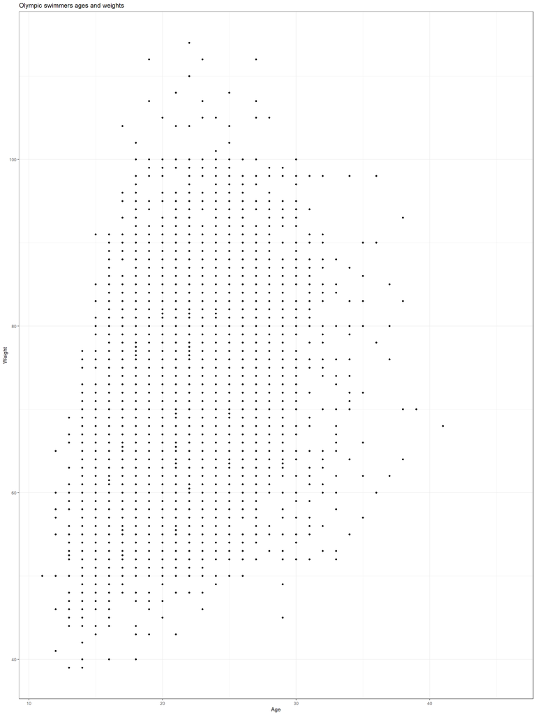

```r
  events %>% filter(Sport == "Swimming") %>%
  ggplot() +
  geom_point(aes(x = Age, y = Weight)) +
  labs(title = 'Olympic swimmers ages and weights') +
  theme_bw()
```

At this stage I still need to find some more research articles that I can replicate to make a story with this data set, There are still many avenues that I can follow up with.